# Financial Volatility Analysis of Alibaba Stock

2020/4/16

[output not shown]

# 1. Introduction

Return on Investment measures the gain or loss generated on an investment relative to the amount of money invested.[1] However, the variability of the returns (called the volatility) can fluctuate considerably. Understanding this volatility is important for quantifying and managing the risk of investments.[2] In this project, I mainly investigate the stock price fluctuation of a Chinese technology company, Alibaba. I would apply both the GARCH model and the POMP framework for Alibaba stock price dataset. Furthermore, since Alibaba is one of the most representative technology companies in China, it is worthwhile to investigate such a company.

# 2. Exploratory Data Analysis

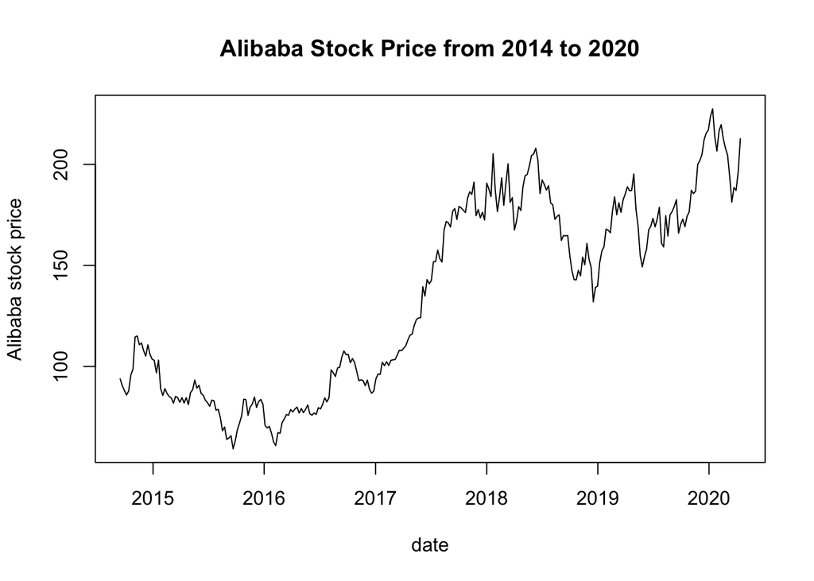

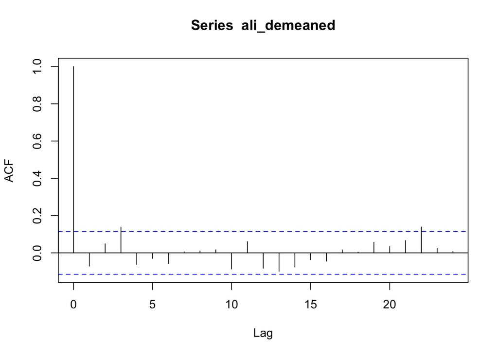

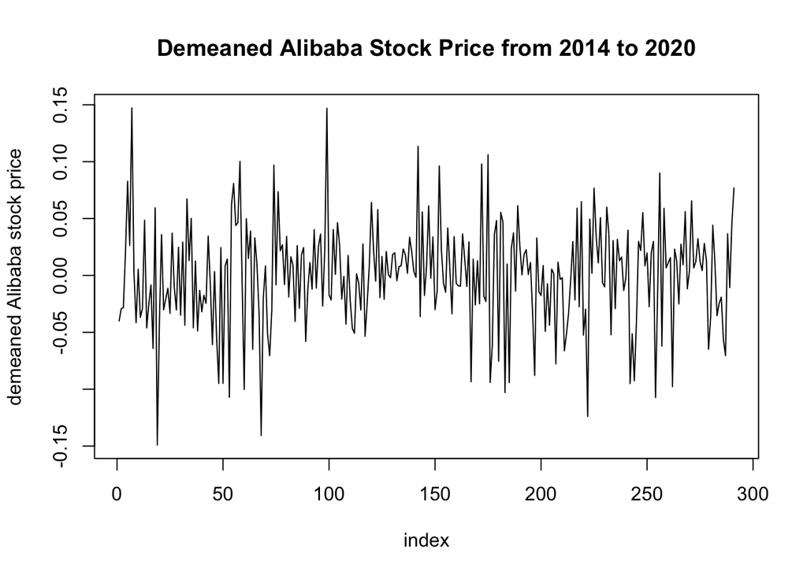

# 3. Model Selection

## 3.1 GARCH model

The generalized autoregressive conditional heteroskedasticity model, also known as GARCH(p, q) model, is widely used in time series analysis. It has the form $Y_{n}=\epsilon_{n} \sqrt{V_{n}}$ where $V_{n}=\alpha_{0}+\sum_{j=1}^{p} \alpha_{j} Y_{n-j}^{2}+\sum_{k=1}^{q} \beta_{k} V_{n-k}$ and $\epsilon_{1: N}$ is white noise.[2] I would apply the GARCH(1,1) model here, which is a popular choice.

```r
ali_garch = garch(ali_demeaned, grad="numerical", trace=FALSE)
tseries:::logLik.garch(ali_garch)
```

```
## 'log Lik.' 482.6987 (df=3)
```

The above GARCH model has a maximized log likelihhood of 482.70, and I set this value as the benchmark, which could be compared with my following model. Firthermore, the reason I do not dig more about the GARCH is GARCH is a black-box model, whose parameters do not have clear interpretation.[2]

## 3.2 POMP model

### Financial Leverage

Financial leverage means that negative shocks to a stockmarket index are associated with a subsequent increase in volatility. The leverage is defined as on day n the correlation between index return on day n-1 and the increase in the log volatility from day n-1 to day n. The formula of the $R_{n}$ is $R_{n}=\frac{\exp \left\{2 G_{n}\right\}-1}{\exp \left\{2 G_{n}\right\}+1}$, where {$G_{n}$} is the usual, Gaussian random walk.[2]

### Building a POMP model

Then, we propose the model by the following equations, $Y_{n}=\exp \left\{H_{n} / 2\right\} \epsilon_{n}$, $H_{n}=\mu_{h}(1-\phi)+\phi H_{n-1}+\beta_{n-1} R_{n} \exp \left\{-H_{n-1} / 2\right\}+\omega_{n}$, $G_{n}=G_{n-1}+\nu_{n}$,

We code the state variables, regular parameters, initial value parameters.

```r
ali_statenames = c("H", "G", "Y_state")
ali_rp_names = c("sigma_nu", "mu_h", "phi", "sigma_eta")
ali_ivp_names = c("G_0", "H_0")
ali_paramnames = c(ali_rp_names, ali_ivp_names)
```

we build two different pomp objetcs, one to do filtering and another to do simulation.

```r
rproc1 = "
  double beta, omega, nu;
  omega = rnorm(0, sigma_eta * sqrt(1-phi*phi)*
    sqrt(1-tanh(G)*tanh(G)));
  nu = rnorm(0, sigma_nu);
  G += nu;
  beta = Y_state * sigma_eta * sqrt( 1- phi*phi );
  H = mu_h*(1 - phi) + phi*H + beta * tanh( G ) * exp(-H/2) + omega;
"

rproc2.sim = "Y_state = rnorm( 0,exp(H/2) );"

rproc2.filt = "Y_state = covaryt;"

ali_rproc.sim = paste(rproc1, rproc2.sim)
ali_rproc.filt = paste(rproc1, rproc2.filt)

ali_rinit = "
  G = G_0;
  H = H_0;
  Y_state = rnorm( 0,exp(H/2) );
"
```

```r
ali_rmeasure = "
  y=Y_state;
"

ali_dmeasure = "
  lik=dnorm(y,0,exp(H/2),give_log);
"
```

we do the parameters transformation below for optimization procedures such as iterated filtering.[2]

```r
ali_partrans <- parameter_trans(
  log=c("sigma_eta","sigma_nu"),
  logit="phi"
)
```

We build the pomp object suitable for filtering.[2]

```r
ali.filt <- pomp(data=data.frame(
    y=ali_demeaned,time=1:length(ali_demeaned)),
  statenames=ali_statenames,
  paramnames=ali_paramnames,
  times="time",
  t0=0,
  covar=covariate_table(
    time=0:length(ali_demeaned),
    covaryt=c(0,ali_demeaned),
    times="time"),
  rmeasure=Csnippet(ali_rmeasure),
  dmeasure=Csnippet(ali_dmeasure),
  rprocess=discrete_time(step.fun=Csnippet(ali_rproc.filt),
    delta.t=1),
  rinit=Csnippet(ali_rinit),
  partrans=ali_partrans
)
```

Then we simulate from the model, and initializ parameters randomly.

```r
params_test <- c(
  sigma_nu = exp(-4.5),
  mu_h = -0.25,
  phi = expit(4),
  sigma_eta = exp(-0.07),
  G_0 = 0,
  H_0=0
)

sim1.sim <- pomp(ali.filt,
  statenames=ali_statenames,
  paramnames=ali_paramnames,
  rprocess=discrete_time(
    step.fun=Csnippet(ali_rproc.sim),delta.t=1)
)

sim1.sim <- simulate(sim1.sim,seed=1,params=params_test)
```

We build the filtering object from the new simulated data

```r
sim1.filt <- pomp(sim1.sim,
  covar=covariate_table(
    time=c(timezero(sim1.sim),time(sim1.sim)),
    covaryt=c(obs(sim1.sim),NA),
    times="time"),
  statenames=ali_statenames,
  paramnames=ali_paramnames,
  rprocess=discrete_time(
    step.fun=Csnippet(ali_rproc.filt),delta.t=1)
)
```

### Filtering on simulated data

We filter and re-estimate parameters

```r
run_level <- 3
ali_Np <- switch(run_level, 100, 1e3, 2e3)
ali_Nmif <- switch(run_level, 10, 100, 200)
ali_Nreps_eval <- switch(run_level, 4, 10, 20)
ali_Nreps_local <- switch(run_level, 10, 20, 20)
ali_Nreps_global <- switch(run_level, 10, 20, 100)
```

```r
registerDoParallel()

stew(file=sprintf("pf1-%d.rda",run_level),{
  t.pf1 <- system.time(
    pf1 <- foreach(i=1:ali_Nreps_eval,
      .packages='pomp') %dopar% pfilter(sim1.filt,Np=ali_Np))
},seed=493536993,kind="L'Ecuyer")
(L.pf1 <- logmeanexp(sapply(pf1,logLik),se=TRUE))
```

```
##                          se
## -432.25840627    0.02949025
```

### Fitting the stochastic leverage model

we will use the iterated filtering algorithm, also known as IF2, of lonides. Theoretically, this procedure converges toward the region of parameter space maximizing the maximum likelihood.[4]

```r
ali_rw.sd_rp <- 0.02
ali_rw.sd_ivp <- 0.1
ali_cooling.fraction.50 <- 0.5
ali_rw.sd <- rw.sd(
  sigma_nu = ali_rw.sd_rp,
  mu_h = ali_rw.sd_rp,
  phi = ali_rw.sd_rp,
  sigma_eta = ali_rw.sd_rp,
  G_0 = ivp(ali_rw.sd_ivp),
  H_0 = ivp(ali_rw.sd_ivp)
)

stew(file=sprintf("mif1-%d.rda",run_level),{
  t.if1 <- system.time({
  if1 <- foreach(i=1:ali_Nreps_local,
    .packages='pomp', .combine=c) %dopar% mif2(ali.filt,
      params=params_test,
      Np=ali_Np,
      Nmif=ali_Nmif,
      cooling.fraction.50=ali_cooling.fraction.50,
      rw.sd = ali_rw.sd)
  L.if1 <- foreach(i=1:ali_Nreps_local,
    .packages='pomp', .combine=rbind) %dopar% logmeanexp(
      replicate(ali_Nreps_eval, logLik(pfilter(ali.filt,
        params=coef(if1[[i]]),Np=ali_Np))), se=TRUE)
  })
},seed=318817883,kind="L'Ecuyer")

r.if1 <- data.frame(logLik=L.if1[,1],logLik_se=L.if1[,2],
  t(sapply(if1,coef)))
if (run_level>1) write.table(r.if1,file="ali_params.csv",
  append=TRUE,col.names=FALSE,row.names=FALSE)

summary(r.if1$logLik, digits=5)
```

```
##    Min. 1st Qu.  Median    Mean 3rd Qu.    Max.
##   475.0   482.3   483.3   483.6   484.8   489.0
```

The maximum likelihood is 489, which is greater than the GARCH model. Meanwhile, we want to check the diagnostic plots to see whether we could improve the model further.

#### Diagnostic plots for the maximization procedure

The convergence plots below show that some parameters could not converge very well.

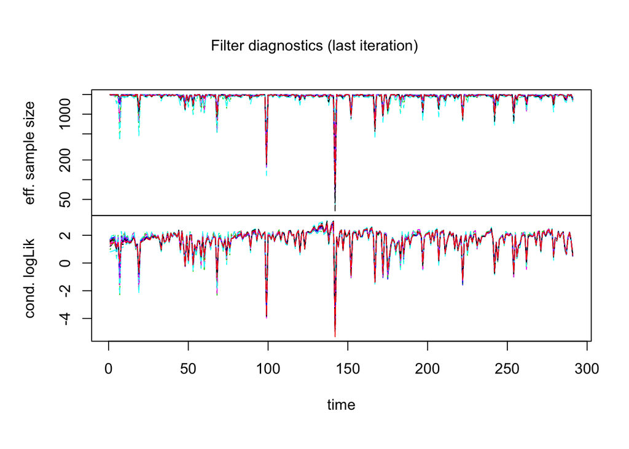

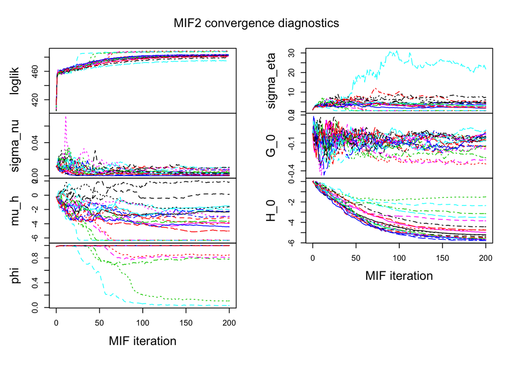

```r
plot(if1)
```

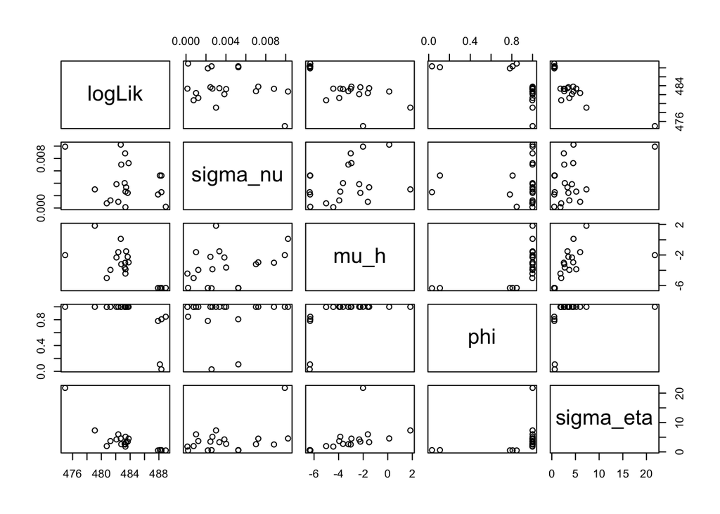

```r
pairs(~logLik+sigma_nu+mu_h+phi+sigma_eta,
  data=subset(r.if1,logLik>max(logLik)-20))
```

### Likelihood maximization using randomized starting values

we try a large box of parameters based on the graphs above to lead to the evidence of global maximization.

```r
ali_box <- rbind(
  sigma_nu=c(0.000,0.05),
  mu_h =c(-6,2),
  phi = c(0.95,0.99),
  sigma_eta = c(0.1,5),
  G_0 = c(-2,2),
  H_0 = c(-1,1)
)
```

```r
stew(file=sprintf("box_eval-%d.rda",run_level),{
  t.box <- system.time({
    if.box <- foreach(i=1:ali_Nreps_global,
      .packages='pomp',.combine=c) %dopar% mif2(if1[[1]],
        params=apply(ali_box,1,function(x)runif(1,x)))
      L.box <- foreach(i=1:ali_Nreps_global,
        .packages='pomp',.combine=rbind) %dopar% {
          logmeanexp(replicate(ali_Nreps_eval, logLik(pfilter(
              ali.filt,params=coef(if.box[[i]]),Np=ali_Np))),
            se=TRUE)
        }
  })
},seed=290860873,kind="L'Ecuyer")

r.box <- data.frame(logLik=L.box[,1],logLik_se=L.box[,2],
  t(sapply(if.box,coef)))
if(run_level>1) write.table(r.box,file="ali_params.csv",
  append=TRUE,col.names=FALSE,row.names=FALSE)
summary(r.box$logLik,digits=5)
```

```
##    Min. 1st Qu.  Median    Mean 3rd Qu.    Max.
##   463.3   484.5   488.3   485.9   488.3   489.1
```

The new maximum log-likelihood has the value 489.1, which is a little bit larger than the previous one.

Based on the convergence plots below, there still have some parameters do not converge. The reason might be the range of the parameters does not set coorectly, or the value of the cooling fraction is not appropriate. However, the maximum log-likelihood is increased, which means the general direction is correct.

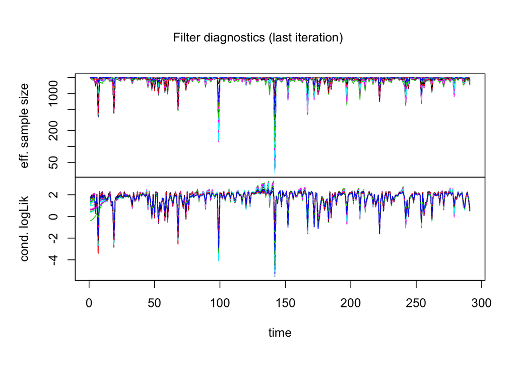

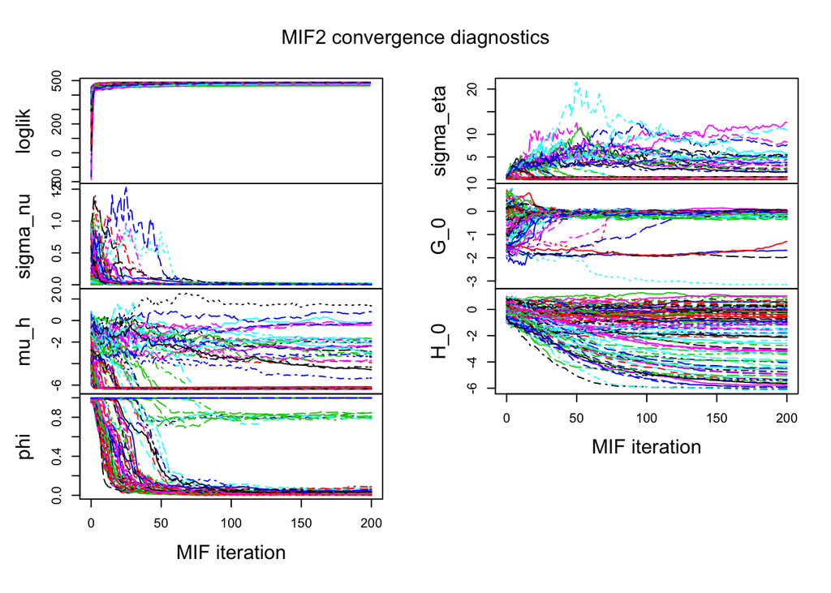

```r
plot(if.box)
```

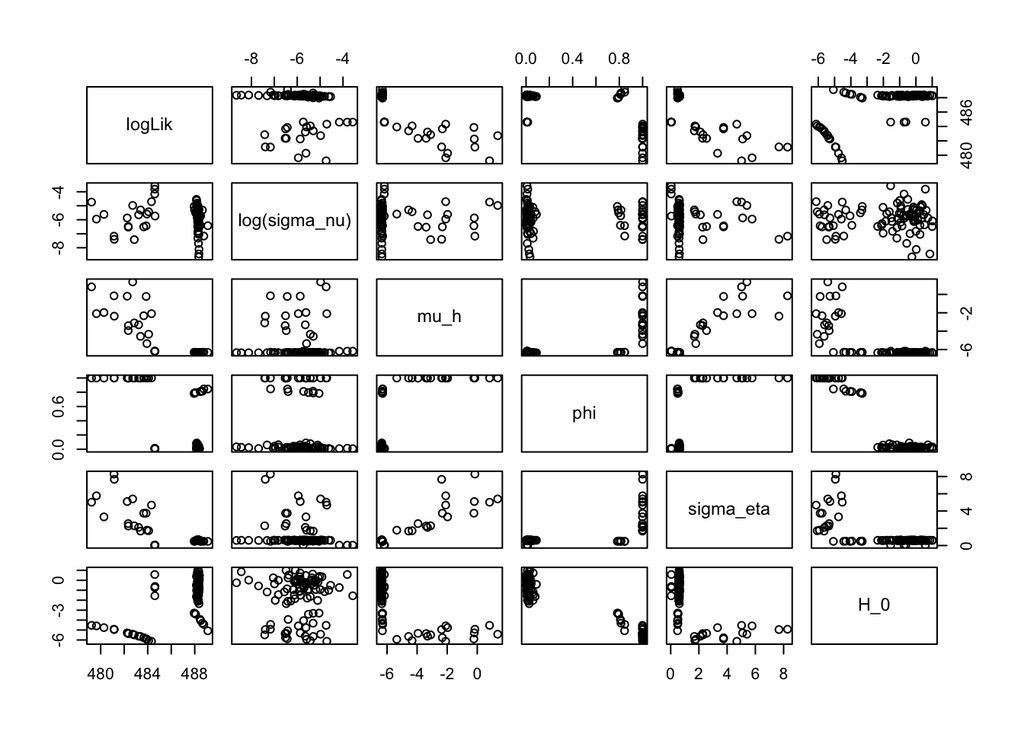

```r
pairs(~logLik+log(sigma_nu)+mu_h+phi+sigma_eta+H_0,
  data=subset(r.box,logLik>max(logLik)-10))
```

# 4. Conclusion

In this project, I mainly use the GARCH and POMP model. The maximum log-likelihood of the GARCH model is 482.7; the maximum log-likelihood of the POMP model with randomized starting values is 489.1. Thus, the POMP model is slightly better. Meanwhile, when checking the diagnostic plots of the POMP model, not all the parameters are converged. Thus, we still could do several works in the future, like increasing the number of particles, changing the cooling fraction and so on.

# Reference

[1]Return on Investment: https://investinganswers.com/dictionary/r/return-investment-roi

[2]STATS 531 note14, https://ionides.github.io/531w20/14/notes14.pdf

[3]Alibaba stock price dataset, https://finance.yahoo.com/quote/baba/history/

[4]STATS 531 note12, https://ionides.github.io/531w20/12/notes12.pdf